# **Best Restaurant Locations in Manhattan**

[figure not shown]

# 1- Introduction

Manhattan is one of the five boroughs that make up New York City, and is the center of the New York metropolitan area. It is also located over the same area as a county of New York state called New York County. Although it is the smallest borough, it is the most densely populated borough. Manhattan is an important commercial, financial, and cultural center of both the United States and the world,it has many famous landmarks, tourist attractions, museums, and universities. In this project we'll identify the best Neighborhoods in Manhattan to open a resturant in Manhattan, this will be suitable for investors who are looking for the best place in Manhattan for a resturant that will be with a high profit potentials.

# 2- Data

To check the best Neighborhoods in Manhattan for a restaurant, there are alot of factors that will affect this purpose, but as we'll make a study for a general type restaurant, so we'll focus only on the following aspects: the competition and Prking availability. the datasets to be used are as following:

1- Newyork data : a dataset that contains Newyork's boroughs and neighborhood along with it's coordinates, we'll slice the dataset on borough column, to get the related data to manhattan only.

2- Manhattan venues : a dataset includes all venues in each neighborhood, latitude & longitude for each neighborhood, venue names and it's category. we'll do some explatory analysis on the dataset to get the most common venues in each neighborhood, then merge it to the manhattan data that created from above.

3- Parking Meters GPS Coordinates and Status : a dataset that contains parking meters number, latitude & longitude, and borough, from "NYC opendata". we'll use Nominatim reverse geocoding service, to convert the coordinates to an address then to the corresponding Neighborhood from that address, then we'll group the Neighborhoods by the count of parking meters. then we'll merge it to the above manhattan data, and then prepare it for the clustering model that we'll use to group the neighborhoods by there similarty to each other, and based on that we'll check the clusters and identify which groups are suitable for our purpose.

# 3- Methodology

Now we load and explore the data

- Let's start by Newyork data

```python
with open('newyork_data.json') as json_data:
    newyork_data = json.load(json_data)
neighborhoods_data = newyork_data['features']
neighborhoods_data[0]
```

```
{'type': 'Feature',
 'id': 'nyu_2451_34572.1',
 'geometry': {'type': 'Point',
  'coordinates': [-73.84720052054902, 40.89470517661]},
 'geometry_name': 'geom',
 'properties': {'name': 'Wakefield',
  'stacked': 1,
  'annoline1': 'Wakefield',
  'annoline2': None,
  'annoline3': None,
  'annoangle': 0.0,
  'borough': 'Bronx',
  'bbox': [-73.84720052054902,
   40.89470517661,
   -73.84720052054902,
   40.89470517661]}}
```

```python
# Transforming the data into Pandas dataframe.
column_names = ['Borough', 'Neighborhood', 'Latitude', 'Longitude']
neighborhoods = pd.DataFrame(columns=column_names)
# looping through the data and fill the dataframe one row at a time
for data in neighborhoods_data:
    borough = neighborhood_name = data['properties']['borough']
    neighborhood_name = data['properties']['name']
    neighborhood_latlon = data['geometry']['coordinates']
    neighborhood_lat = neighborhood_latlon[1]
    neighborhood_lon = neighborhood_latlon[0]
    neighborhoods = neighborhoods.append({'Borough': borough,
                                          'Neighborhood': neighborhood_name,
                                          'Latitude': neighborhood_lat,
                                          'Longitude': neighborhood_lon}, ignore_index=True)


neighborhoods.head()
```

|  | Borough | Neighborhood | Latitude | Longitude |
| --- | --- | --- | --- | --- |
| 0 | Bronx | Wakefield | 40.894705 | -73.847201 |
| 1 | Bronx | Co-op City | 40.874294 | -73.829939 |
| 2 | Bronx | Eastchester | 40.887556 | -73.827806 |
| 3 | Bronx | Fieldston | 40.895437 | -73.905643 |
| 4 | Bronx | Riverdale | 40.890834 | -73.912585 |

```python
manhattan_data = neighborhoods[neighborhoods['Borough'] == 'Manhattan'].reset_index(drop=True)
print('Manhattan has {} Neighborhood'.format(manhattan_data.shape[0]))
manhattan_data.head()
```

```
Manhattan has 40 Neighborhood
```

|  | Borough | Neighborhood | Latitude | Longitude |
| --- | --- | --- | --- | --- |
| 0 | Manhattan | Marble Hill | 40.876551 | -73.910660 |
| 1 | Manhattan | Chinatown | 40.715618 | -73.994279 |
| 2 | Manhattan | Washington Heights | 40.851903 | -73.936900 |
| 3 | Manhattan | Inwood | 40.867684 | -73.921210 |
| 4 | Manhattan | Hamilton Heights | 40.823604 | -73.949688 |

- Now let's download and explore Manhattan venues dataset.

```python
manhattan_venues = pd.read_json('manhattan_venues.json')
manhattan_venues.head()
```

|  | Neighborhood | Neighborhood Latitude | Neighborhood Longitude | Venue | Venue Latitude | Venue Longitude | Venue Category |
| --- | --- | --- | --- | --- | --- | --- | --- |
| 0 | Marble Hill | 40.876551 | -73.91066 | Arturo's | 40.874412 | -73.910271 | Pizza Place |
| 1 | Marble Hill | 40.876551 | -73.91066 | Bikram Yoga | 40.876844 | -73.906204 | Yoga Studio |
| 2 | Marble Hill | 40.876551 | -73.91066 | Tibbett Diner | 40.880404 | -73.908937 | Diner |
| 3 | Marble Hill | 40.876551 | -73.91066 | Dunkin' | 40.877136 | -73.906666 | Donut Shop |
| 4 | Marble Hill | 40.876551 | -73.91066 | Starbucks | 40.877531 | -73.905582 | Coffee Shop |

```python
print('Manhattan has {} Neighborhood with total {} venues'.format(len(manhattan_venues['Neighborhood'].unique()),
                                                                  manhattan_venues.shape[0]))
```

```
Manhattan has 40 Neighborhood with total 3240 venues
```

- we'll check the top 10 venues in Manhattan.

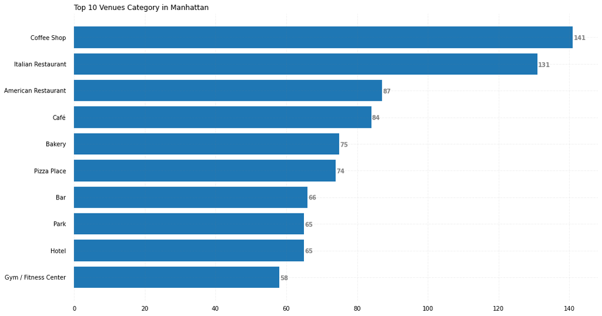

```python
top_10 = manhattan_venues['Venue Category'].value_counts().head(10).to_frame().reset_index()
top_10.columns = ['Venue Category', 'count']

import matplotlib.pyplot as plt
# Figure Size
fig, ax = plt.subplots(figsize =(16, 9))

# Horizontal Bar Plot
ax.barh(top_10['Venue Category'], top_10['count'])

# Remove axes splines
for s in ['top', 'bottom', 'left', 'right']:
    ax.spines[s].set_visible(False)

# Remove x, y Ticks
ax.xaxis.set_ticks_position('none')
ax.yaxis.set_ticks_position('none')

# Add padding between axes and labels
ax.xaxis.set_tick_params(pad = 5)
ax.yaxis.set_tick_params(pad = 10)

# Add x, y gridlines
ax.grid(b = True, color ='grey',
        linestyle ='-.', linewidth = 0.5,
        alpha = 0.2)

# Show top values
ax.invert_yaxis()

# Add annotation to bars
for i in ax.patches:
    plt.text(i.get_width()+0.2, i.get_y()+0.5,
             str(round((i.get_width()), 2)),
             fontsize = 10, fontweight ='bold',
             color ='grey')

# Add Plot Title
ax.set_title('Top 10 Venues Category in Manhattan',
             loc ='left', )

# Show Plot
plt.show()
```

- Let's identify the nature of each Neighborhood by getting the top 5 most common venues in each neighborhood.

```python
# define a function to sort the venues in descending order.
def return_most_common_venues(row, num_top_venues):
    row_categories = row.iloc[1:]
    row_categories_sorted = row_categories.sort_values(ascending=False)

    return row_categories_sorted.index.values[0:num_top_venues]

# create the sorted data frame
num_top_venues = 5
indicators = ['st', 'nd', 'rd']
columns = ['Neighborhood'] # create columns according to number of top venues
for ind in np.arange(num_top_venues):
    try:
        columns.append('{}{} Most Common Venue'.format(ind+1, indicators[ind]))
    except:
        columns.append('{}th Most Common Venue'.format(ind+1))

neighborhoods_venues_sorted = pd.DataFrame(columns=columns)
neighborhoods_venues_sorted['Neighborhood'] = manhattan_grouped['Neighborhood']

for ind in np.arange(manhattan_grouped.shape[0]):
    neighborhoods_venues_sorted.iloc[ind, 1:] = return_most_common_venues(manhattan_grouped.iloc[ind, :], num_top_venues)

neighborhoods_venues_sorted.head()
```

|  | Neighborhood | 1st Most Common Venue | 2nd Most Common Venue | 3rd Most Common Venue | 4th Most Common Venue | 5th Most Common Venue |
| --- | --- | --- | --- | --- | --- | --- |
| 0 | Battery Park City | Park | Coffee Shop | Gym | Clothing Store | Hotel |
| 1 | Carnegie Hill | Coffee Shop | Café | Bar | Italian Restaurant | Pizza Place |
| 2 | Central Harlem | African Restaurant | Seafood Restaurant | Cosmetics Shop | Bar | French Restaurant |
| 3 | Chelsea | Coffee Shop | Art Gallery | Bakery | American Restaurant | Italian Restaurant |
| 4 | Chinatown | Chinese Restaurant | Bakery | Dessert Shop | Cocktail Bar | Hotpot Restaurant |

- Next step is to get number of parkings available in each neighborhood.
- so let's download the Parking Meters GPS Coordinates and Status dataset and explore it.

```python
manhattan_parking = pd.read_csv('manhattan_parking.csv')
manhattan_parking = manhattan_parking[['MeterNo','LAT','LONG','Neighborhood']]
manhattan_parking.head()
```

|  | MeterNo | LAT | LONG | Neighborhood |
| --- | --- | --- | --- | --- |
| 0 | 1068277 | 40.863244 | -73.925681 | Fort George |
| 1 | 1068276 | 40.862876 | -73.925443 | Fort George |
| 2 | 1068275 | 40.862783 | -73.925016 | Fort George |
| 3 | 1068274 | 40.862670 | -73.924983 | Fort George |
| 4 | 1068273 | 40.862289 | -73.925066 | Fort George |

```python
manhattan_parking.drop(['LONG','LAT'], axis=1, inplace= True)
manhattan_parking = manhattan_parking.reset_index()
manhattan_parking = manhattan_parking.rename(columns={'MeterNo': 'Parking_No.'})
manhattan_parking.head()
```

[output not shown]

- Let's merge the parking data with the manhattan merged data.

```python
manhattan_merged['Parking_No.'] = manhattan_merged['Parking_No.'].fillna(int(manhattan_merged['Parking_No.'].mean()))
manhattan_merged.head()
```

|  | Borough | Neighborhood | Latitude | Longitude | 1st Most Common Venue | 2nd Most Common Venue | 3rd Most Common Venue | 4th Most Common Venue | 5th Most Common Venue | Parking_No. |
| --- | --- | --- | --- | --- | --- | --- | --- | --- | --- | --- |
| 0 | Manhattan | Marble Hill | 40.876551 | -73.910660 | Gym | Discount Store | Coffee Shop | Sandwich Place | Yoga Studio | 72.0 |
| 1 | Manhattan | Chinatown | 40.715618 | -73.994279 | Chinese Restaurant | Bakery | Dessert Shop | Cocktail Bar | Hotpot Restaurant | 74.0 |
| 2 | Manhattan | Washington Heights | 40.851903 | -73.936900 | Café | Bakery | Mobile Phone Shop | Deli / Bodega | Gym | 72.0 |
| 3 | Manhattan | Inwood | 40.867684 | -73.921210 | Mexican Restaurant | Café | Restaurant | Lounge | Chinese Restaurant | 32.0 |
| 4 | Manhattan | Hamilton Heights | 40.823604 | -73.949688 | Pizza Place | Café | Coffee Shop | Deli / Bodega | Mexican Restaurant | 44.0 |

- Now our dataset is ready, let's build a clustering model for Manhattan Neighborhoods.
- We'll use K-means to cluster the Neighborhoods, and to do that let's get the optimal value of K.
- Elbow method :

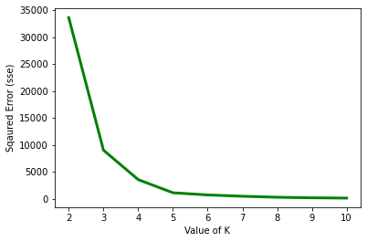

```python
import matplotlib.pyplot as plt
from sklearn.cluster import KMeans
sse =[]
Kmax= 10
manhattan_clustering = manhattan_clustering.drop('Neighborhood', 1)
for k in range(2, Kmax+1):
    KM = KMeans(n_clusters = k, max_iter = 500)
    KM.fit(manhattan_clustering)

    # calculates squared error
    sse.append(KM.inertia_)

# plot the sse against K values
plt.plot(range(2, Kmax+1), sse, color ='g', linewidth ='3')
plt.xlabel("Value of K")
plt.ylabel("Sqaured Error (sse)")
plt.show() # clear the plot
```

- Silhouette_score method :

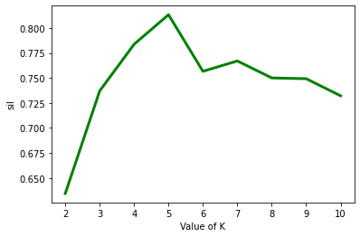

```python
# getting the optimal value of K at highest silhouette_score
from sklearn.metrics import silhouette_score

sil = []
# dissimilarity would not be defined for a single cluster, thus, minimum number of clusters should be 2
for k in range(2, Kmax+1):
    kmeans = KMeans(n_clusters = k, max_iter = 500).fit(manhattan_clustering)
    labels = kmeans.labels_
    sil.append(silhouette_score(manhattan_clustering, labels, metric = 'euclidean'))

# plot the sil against K values
plt.plot(range(2, Kmax+1), sil, color ='g', linewidth ='3')
plt.xlabel("Value of K")
plt.ylabel("sil")
plt.show()
```

From the two methods, the optimal value of K is 5, so let's run the model based on this value.

```python
kclusters = 5
# run k-means clustering
kmeans = KMeans(n_clusters=kclusters, random_state=0).fit(manhattan_clustering)

# check cluster labels generated for each row in the dataframe
kmeans.labels_
```

```
array([2, 0, 0, 1, 0, 2, 0, 0, 1, 0, 0, 0, 0, 4, 2, 4, 1, 2, 4, 3, 0, 2,
       0, 0, 3, 4, 3, 0, 0, 0, 0, 0, 4, 2, 3, 0, 0, 0, 0, 0])
```

- Let's add the cluster labels to manhattan merged dataset.

```python
# add clustering labels
manhattan_merged.insert(4, 'Cluster Labels', kmeans.labels_)
manhattan_merged.head()
```

|  | Borough | Neighborhood | Latitude | Longitude | Cluster Labels | 1st Most Common Venue | 2nd Most Common Venue | 3rd Most Common Venue | 4th Most Common Venue | 5th Most Common Venue | Parking_No. |
| --- | --- | --- | --- | --- | --- | --- | --- | --- | --- | --- | --- |
| 0 | Manhattan | Marble Hill | 40.876551 | -73.910660 | 2 | Gym | Discount Store | Coffee Shop | Sandwich Place | Yoga Studio | 72.0 |
| 1 | Manhattan | Chinatown | 40.715618 | -73.994279 | 0 | Chinese Restaurant | Bakery | Dessert Shop | Cocktail Bar | Hotpot Restaurant | 74.0 |
| 2 | Manhattan | Washington Heights | 40.851903 | -73.936900 | 0 | Café | Bakery | Mobile Phone Shop | Deli / Bodega | Gym | 72.0 |
| 3 | Manhattan | Inwood | 40.867684 | -73.921210 | 1 | Mexican Restaurant | Café | Restaurant | Lounge | Chinese Restaurant | 32.0 |
| 4 | Manhattan | Hamilton Heights | 40.823604 | -73.949688 | 0 | Pizza Place | Café | Coffee Shop | Deli / Bodega | Mexican Restaurant | 44.0 |

- Let's create a map to visualize the Clusters.

```python
import matplotlib.cm as cm
import matplotlib.colors as colors
latitude = 40.7831
longitude = -73.9712

map_clusters = folium.Map(location=[latitude, longitude], zoom_start=11)

# set color scheme for the clusters
x = np.arange(kclusters)
ys = [i + x + (i*x)**2 for i in range(kclusters)]
colors_array = cm.rainbow(np.linspace(0, 1, len(ys)))
rainbow = [colors.rgb2hex(i) for i in colors_array]

# add markers to the map
markers_colors = []
for lat, lon, poi, cluster in zip(manhattan_merged['Latitude'], manhattan_merged['Longitude'], manhattan_merged['Neighborhood'], manhattan_merged['Cluster Labels']):
    label = folium.Popup(str(poi) + ' Cluster ' + str(cluster), parse_html=True)
    folium.CircleMarker(
        [lat, lon],
        radius=5,
        popup=label,
        color=rainbow[cluster-1],
        fill=True,
        fill_color=rainbow[cluster-1],
        fill_opacity=0.7).add_to(map_clusters)

map_clusters
```

Make this Notebook Trusted to load map: File -> Trust Notebook

[interactive chart not shown]

- Clusters Venues summary :

```python
data = {'1st Most Common Venue':[cluster_1['1st Most Common Venue'].value_counts().head(1).to_frame().index[0],
                                cluster_2['1st Most Common Venue'].value_counts().head(1).to_frame().index[0],
                                cluster_3['1st Most Common Venue'].value_counts().head(1).to_frame().index[0],
                                cluster_4['1st Most Common Venue'].value_counts().head(1).to_frame().index[0],
                                cluster_5['1st Most Common Venue'].value_counts().head(1).to_frame().index[0]],
       '2nd Most Common Venue':[cluster_1['2nd Most Common Venue'].value_counts().head(1).to_frame().index[0],
                               cluster_2['2nd Most Common Venue'].value_counts().head(1).to_frame().index[0],
                               cluster_3['2nd Most Common Venue'].value_counts().head(1).to_frame().index[0],
                               cluster_4['2nd Most Common Venue'].value_counts().head(1).to_frame().index[0],
                               cluster_5['2nd Most Common Venue'].value_counts().head(1).to_frame().index[0]],
       '3rd Most Common Venue':[cluster_1['3rd Most Common Venue'].value_counts().head(1).to_frame().index[0],
                               cluster_2['3rd Most Common Venue'].value_counts().head(1).to_frame().index[0],
                               cluster_3['3rd Most Common Venue'].value_counts().head(1).to_frame().index[0],
                               cluster_4['3rd Most Common Venue'].value_counts().head(1).to_frame().index[0],
                               cluster_5['3rd Most Common Venue'].value_counts().head(1).to_frame().index[0]],
       '4th Most Common Venue':[cluster_1['4th Most Common Venue'].value_counts().head(1).to_frame().index[0],
                               cluster_2['4th Most Common Venue'].value_counts().head(1).to_frame().index[0],
                               cluster_3['4th Most Common Venue'].value_counts().head(1).to_frame().index[0],
                               cluster_4['4th Most Common Venue'].value_counts().head(1).to_frame().index[0],
                               cluster_5['4th Most Common Venue'].value_counts().head(1).to_frame().index[0]],
       '5th Most Common Venue':[cluster_1['5th Most Common Venue'].value_counts().head(1).to_frame().index[0],
                               cluster_2['5th Most Common Venue'].value_counts().head(1).to_frame().index[0],
                               cluster_3['5th Most Common Venue'].value_counts().head(1).to_frame().index[0],
                               cluster_4['5th Most Common Venue'].value_counts().head(1).to_frame().index[0],
                               cluster_5['5th Most Common Venue'].value_counts().head(1).to_frame().index[0]]}
df = pd.DataFrame(data, index=['cluster 1','cluster 2','cluster 3','cluster 4','cluster 5'])
df
```

|  | 1st Most Common Venue | 2nd Most Common Venue | 3rd Most Common Venue | 4th Most Common Venue | 5th Most Common Venue |
| --- | --- | --- | --- | --- | --- |
| cluster 1 | Italian Restaurant | Bakery | Café | Cocktail Bar | Pizza Place |
| cluster 2 | Mexican Restaurant | Coffee Shop | Restaurant | Sandwich Place | American Restaurant |
| cluster 3 | Seafood Restaurant | Hotel | Hotel Bar | American Restaurant | Cosmetics Shop |
| cluster 4 | Italian Restaurant | Pizza Place | Park | American Restaurant | Speakeasy |
| cluster 5 | Mexican Restaurant | Café | Gym / Fitness Center | Gym | Coffee Shop |

# 4- Results & Discussion

- our analysis shows that Neighborhoods in cluster 1,2 & 4 represents a perfect location for a restaurant, the most common venues in these Neighborhoods are a variety of restaurants cuisine and coffe shops, with a fare numbers of parking spots.
- Other clusters can be choosed if you are willing to open a specific restaurant cuisine, based on the Neighborhoods that have the same type of restaurants.
- we choosed the nehighborhoods that have a variety of restaurants and the competition is high because up to the 5th common venue there are restaurants and coffeshops, and there are a lot of parkings too. ofcourse if the restaurant cuisine is konwn, there will be more factors to consider while building the model, such as the distance from the suppliers, the population study of each neighborhood, is it a breakfast restaurant to check the traffic where people are heading to businees centers and work zones, and so on.

# 5- Conclusion

- Purpose of this project was to identify Manhattan Neighborhoods that have a high competition in restaurants and coffeshops in order to aid stakeholders in narrowing down the search for optimal location for a new restaurant, by using a cluster model to group Manhattan Neighborhoods to different clusters that have neighborhoods with similar charactarestics.
- Final decission on optimal restaurant location will be made by stakeholders based on specific characteristics in every recommended neighborhood, taking into consideration additional factors like attractiveness of each location (proximity to park or water), levels of noise / proximity to major roads, real estate availability, prices, social and economic dynamics of every neighborhood etc